# Warsztaty Badawcze - Praca Domowa 1

Ada Gąssowska

15 marca 2020

W pracy domowej 1 na zbiorze danych ‘Credit’ wykorzystam kilka prostych technik imputacji danych. Następnie sprawdzę jak na przygotowanych ramkach działa algorytm knn (k najbliższych sąsiadów).

## Informacje o zbiorze danych ‘Credit’

Zbiór danych “Credit” prezentuje informacje o kredytobiorcach. Będziemy próbowali przewidzień czy dany klient dostanie kretyd, czy nie. Po zmapowaniu na liczby, klasa 1 oznacza że osoba nie dostanie kredytu, a klasa 2 - że nie.

```r
data = read.csv("C:/Users/Ada/Desktop/dataset_29_credit-a.csv")
data[data=="?"] <- NaN #zamieniam znaki zapytania na NaN
data$A2 <- as.numeric(as.character(data$A2))
data$A9 <- as.numeric(as.character(data$A8))

head(data)
```

```
##   A1    A2    A3 A4 A5 A6 A7   A8   A9 A10 A11 A12 A13   A14 A15 class
## 1  b 30.83 0.000  u  g  w  v 1.25 1.25   t   1   f   g 00202   0     +
## 2  a 58.67 4.460  u  g  q  h 3.04 3.04   t   6   f   g 00043 560     +
## 3  a 24.50 0.500  u  g  q  h 1.50 1.50   f   0   f   g 00280 824     +
## 4  b 27.83 1.540  u  g  w  v 3.75 3.75   t   5   t   g 00100   3     +
## 5  b 20.17 5.625  u  g  w  v 1.71 1.71   f   0   f   s 00120   0     +
## 6  b 32.08 4.000  u  g  m  v 2.50 2.50   f   0   t   g 00360   0     +
```

```r
colnames(data) <- c("Sex", "Age", "Debt", "Married", "BankCustomer", "EducationLevel", "Ethicity", "Years employed", "PriorDefault", "Employed", "CreditScore", "Driverslicense", "Citizen", "Zipcode", "Income", "class")
```

## Rozkład zmiennych i braki danych

Sprawdzenie liczby braków danych

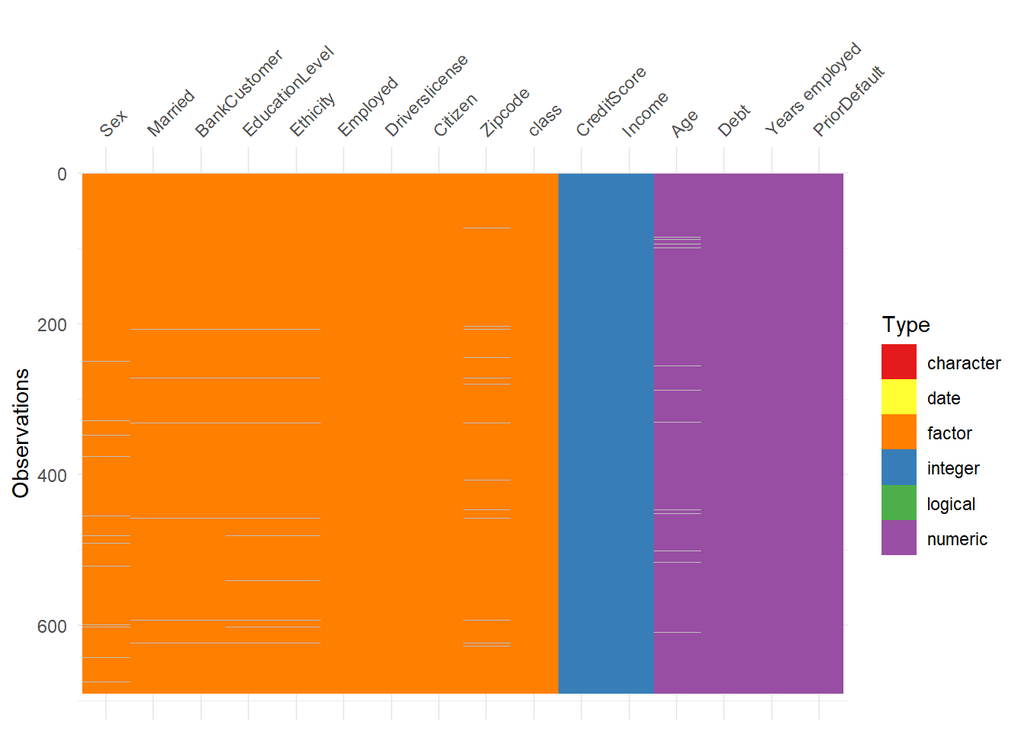

```r
vis_dat(data, palette='qual')
```

```r
data$class <- as.numeric(data$class)
data <- lapply(data, as.numeric)
data<- data.frame(data)

library(purrr)
```

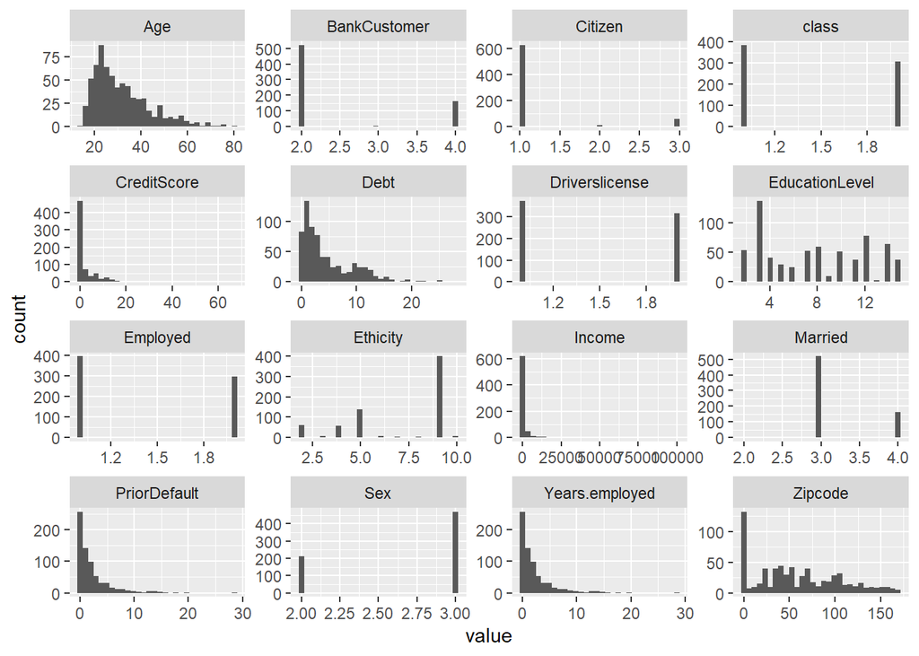

```r
library(tidyr)
library(ggplot2)


data %>%
  keep(is.numeric) %>%
  gather() %>%
  ggplot(aes(value)) +
  facet_wrap(~ key, scales = "free") +
  geom_histogram()
```

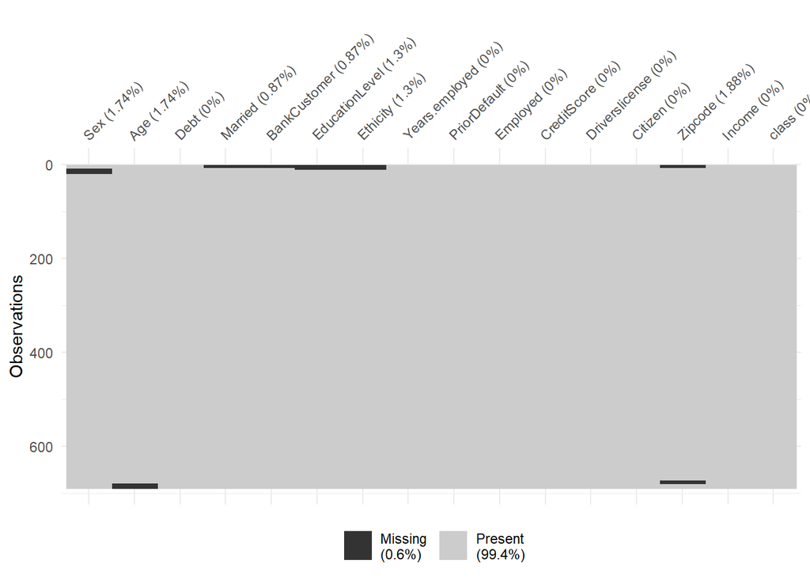

```r
vis_miss(data, cluster = TRUE)
```

```r
miss_var_summary(data)
```

```
## # A tibble: 16 x 3
##    variable       n_miss pct_miss
##    <chr>           <int>    <dbl>
##  1 Zipcode            13    1.88
##  2 Sex                12    1.74
##  3 Age                12    1.74
##  4 EducationLevel      9    1.30
##  5 Ethicity            9    1.30
##  6 Married             6    0.870
##  7 BankCustomer        6    0.870
##  8 Debt                0    0
##  9 Years.employed      0    0
## 10 PriorDefault        0    0
## 11 Employed            0    0
## 12 CreditScore         0    0
## 13 Driverslicense      0    0
## 14 Citizen             0    0
## 15 Income              0    0
## 16 class               0    0
```

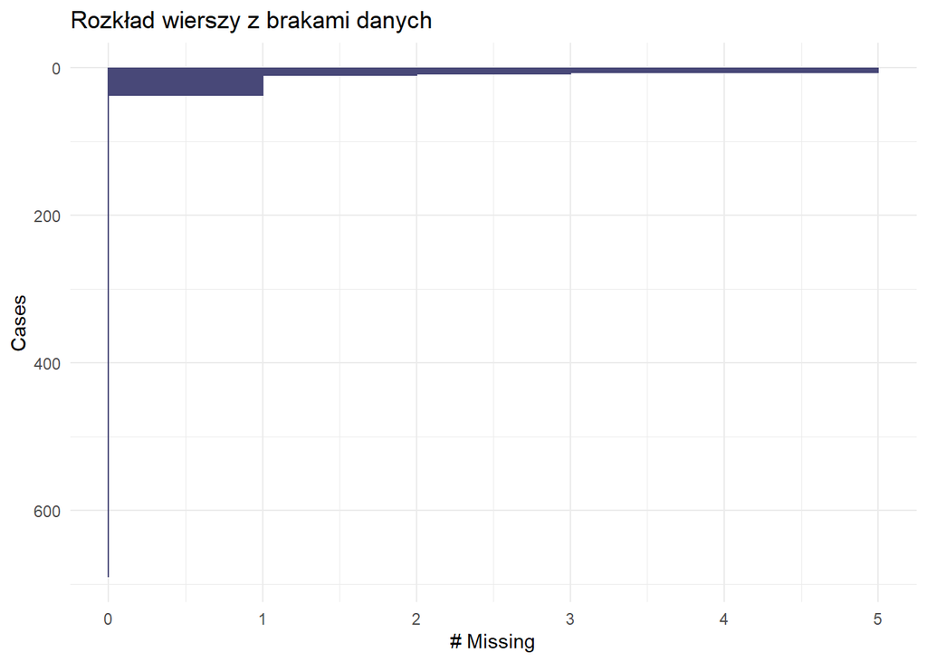

[figure not shown]

[output not shown]

```r
gg_miss_case(data) +ggtitle("Rozkład wierszy z brakami danych")
```

```r
data$class <- as.numeric(data$class)
data <- lapply(data, as.numeric)
data<- data.frame(data)
```

Po wykonaniu rysunków pomocniczych, łatwo zauważyć że większość wierszy jest pełna.

## Usunięcie kolumn z brakami danych

Pierwszą techniką jaką wypróbuję będzie ta najprostsza - usunięcie kolumn w których jest jakiś NaN i spróbowanie przewidzenia klasy na podstawie danych z reszty kolumn.

```
##          Prediction (usuwanie)
## Reference  1  2
##         1 81 17
##         2 29 46
```

```
## type_of_error
## FN FP TN TP
## 17 29 46 81
```

```
## [1] "Accuracy:"
```

[output not shown]

```
## [1] "Error rate:"
```

[output not shown]

```
## [1] "F1:"
```

```
##        TP
## 0.7788462
```

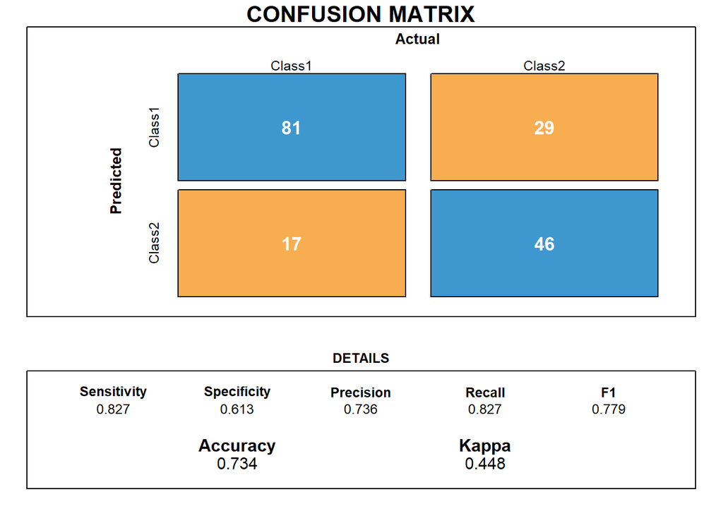

```r
cm <- confusionMatrix(as.factor(prediction), as.factor(df_test$class))



draw_confusion_matrix(cm)
```

## Wypełnienie braków danych modą

Drugą techniką imputacji jaką opiszę będzie wypełnienie braków danych modą.

Jako że R nie ma wbudowanej funckji do liczenia mody napiszę ją sama :

```r
mode <- function(x){
  ux <- unique(x)
  ux[which.max(tabulate(match(x, ux)))]
}
```

```
## [1] "Algorytm zakwalifikował dane następująco:"
```

```
##          Prediction (Moda)
## Reference  1  2
##         1 74 24
##         2 24 51
```

```
## type_of_error
## FN FP TN TP
## 24 24 51 74
```

```
## [1] "Accuracy:"
```

```
##        TP
## 0.7225434
```

```
## [1] "Error rate:"
```

```
##        FP
## 0.2774566
```

```
## [1] "F1:"
```

```
##       TP
## 0.755102
```

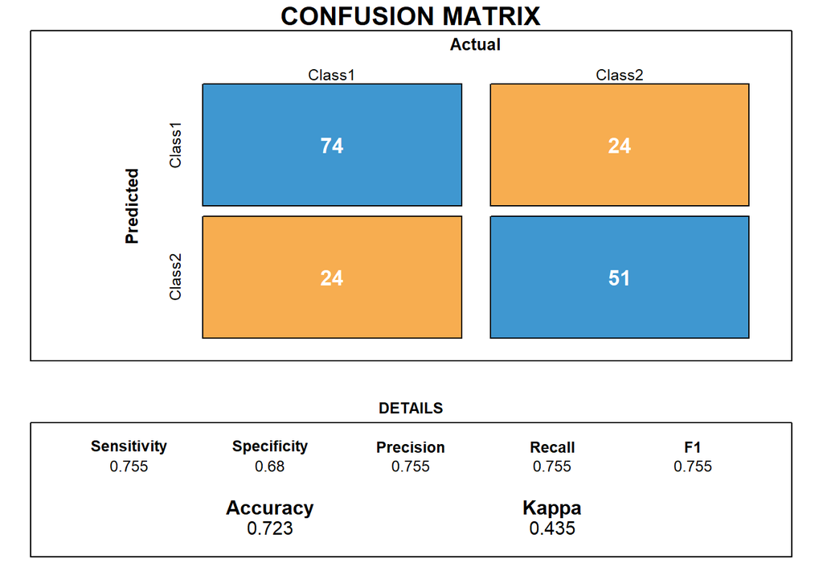

```r
cm <- confusionMatrix(as.factor(prediction), as.factor(df_test$class))



draw_confusion_matrix(cm)
```

## Wypełnianie średnią (dla zmiennych kategorycznych zostawię modę)

Teraz w zmiennych kategorycznych w miejscu braków wstawię modę, a w zmiennych ciągłych - średnią.

```
##          Prediction (Moda/Średnia)
## Reference  1  2
##         1 77 21
##         2 24 51
```

```
## type_of_error
## FN FP TN TP
## 21 24 51 77
```

```
## [1] "Accuracy:"
```

```
##        TP
## 0.7398844
```

```
## [1] "Error rate:"
```

```
##        FP
## 0.2601156
```

```
## [1] "F1:"
```

```
##        TP
## 0.7738693
```

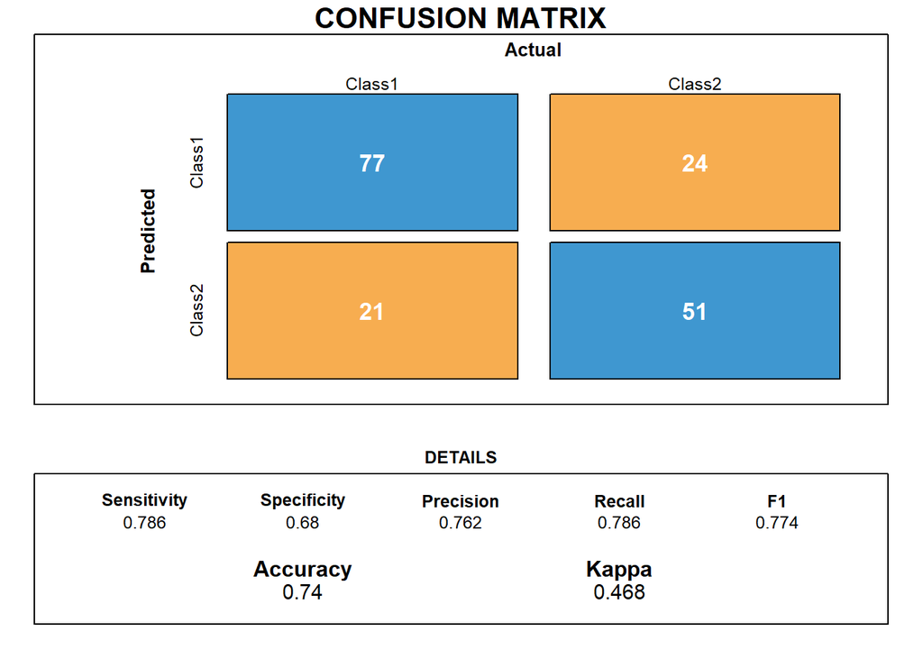

```r
cm <- confusionMatrix(as.factor(prediction), as.factor(df_test$class))



draw_confusion_matrix(cm)
```

## Wypełnianie medianą (dla zmiennych kategorycznych moda)

Podobnie jak w poprzednim punkcie, tylko zamiast średniej - mediana.

```
##          Prediction (Moda/Mediana)
## Reference  1  2
##         1 77 21
##         2 24 51
```

```
## type_of_error
## FN FP TN TP
## 21 24 51 77
```

```
## [1] "Accuracy:"
```

```
##        TP
## 0.7398844
```

```
## [1] "Error rate:"
```

```
##        FP
## 0.2601156
```

```
## [1] "F1:"
```

```
##        TP
## 0.7738693
```

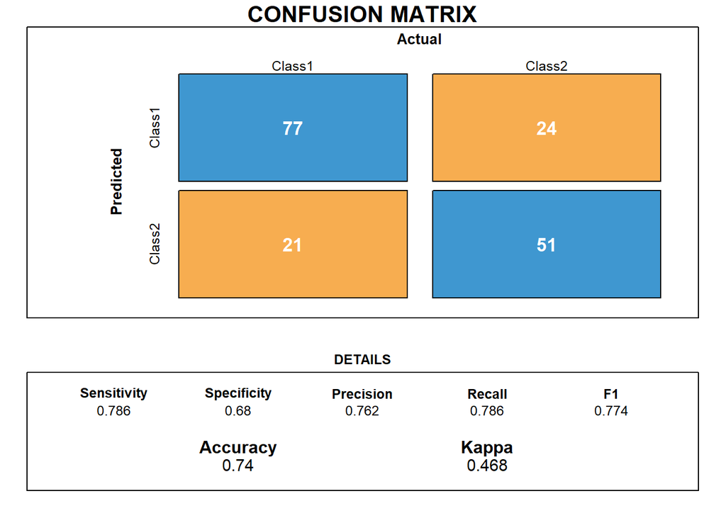

```r
cm <- confusionMatrix(as.factor(prediction), as.factor(df_test$class))



draw_confusion_matrix(cm)
```